# Visualization of Maternal Mortality

Short Paper Assignment

Andrea L. Koch

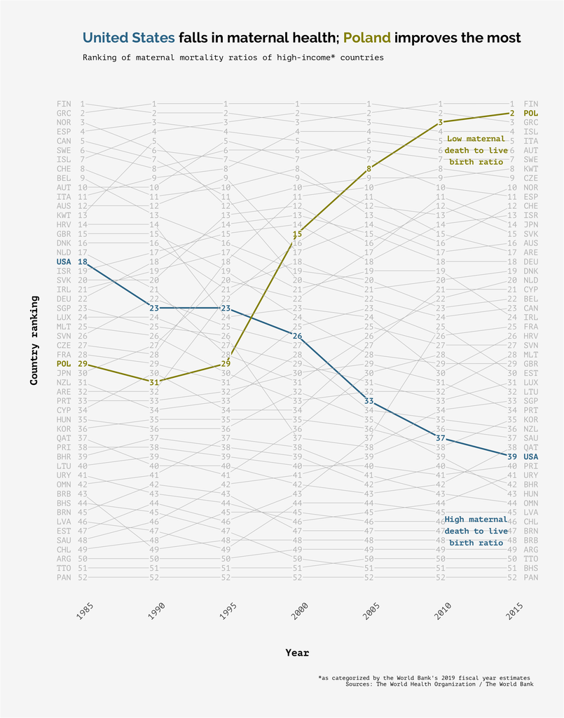

```r
#######################
#      BUMPCHART      #
#  plot upper income  #
#######################

####  Filter and merge data:

WHO_data <- read.csv("data/WHO_MMR-data-1990-2015 (1)/countryresults_all.csv")

# New table of mmr point estimates:
mmr_data <- filter(WHO_data,
                     indicator == "mmr",
                     estimate == "point estimate",
                     rounded == "FALSE")

WorldBank_data <- read_excel("data/WB_country_region_income.xlsx")
WorldBank_data <- WorldBank_data[,-c(3,6,7)]

# Merge WHO and WB data:
merged_WHO_WB_data <- sqldf("SELECT * from mmr_data
                  LEFT OUTER join WorldBank_data
                  ON mmr_data.iso = WorldBank_data.Code")



####  Create subsets by income, then rank countries by maternal mortality ratio (mmr):

upper_income_countries <- filter(merged_WHO_WB_data, `Income group` == "High income")

ranked_mmr_of_upper_income <- arrange(upper_income_countries, year, value) %>%
  group_by(year) %>%
  mutate(rank = order(value))


#### Find changes in rank from 1985 to 2015 for:


  # UPPER INCOME COUNTRIES
change_in_rank_upper <-  subset(ranked_mmr_of_upper_income, year %in% c(1985, 2015))
change_in_rank_upper <- change_in_rank_upper[,-c(4:11)]
change_in_rank_upper <- spread(change_in_rank_upper, year, rank)
change_in_rank_upper[3:4] <- lapply(change_in_rank_upper[3:4], as.numeric)
change_in_rank_upper <- mutate(change_in_rank_upper, rank_change = change_in_rank_upper$`1985` - change_in_rank_upper$`2015`)
  # NB: United States (USA) fell by 21 spots, Poland (POL) gained by 27 spots


# Show only every 5 years:
show_years <- c(2015, 2010, 2005, 2000, 1995, 1990, 1985)

ranked_mmr_of_upper_income$Year_formatted <- as.character(ranked_mmr_of_upper_income$year)
ranked_mmr_of_upper_income <- subset(ranked_mmr_of_upper_income, year %in% show_years)


# Note rows for USA (down) and POL (up), so that they can be highlighted later in visualization:
ranked_mmr_of_upper_income <- mutate(ranked_mmr_of_upper_income,
                                     highlight_country = case_when(iso == "USA" ~ 1,
                                                                   iso == "POL" ~ 2,
                                                                   TRUE ~ 0))


#### PLOT

background_color <- "#F7F7F7"
gridline_color_light <- "#EBEBEB"
gridline_color_dark <- "#8A8A8A"
title_font <- "Raleway"
subtitle_font <- "PT Mono"
caption_font <- "PT Mono"

  # NB: United States (USA) fell by 21 spots, Poland (POL) gained by 27 spots

down_color <- "#357797"
up_color <- "#948E00"

df <- ranked_mmr_of_upper_income

ggplot(data = df, aes(x = year, y = rank, group = iso)) +
  scale_y_reverse() +

  # USA:
  geom_line(data = df %>% filter(iso == "USA"), alpha = 1, color = down_color, size = 1) +
  geom_label(data = df %>% filter(iso == "USA"),
             aes(label = rank),
             size = 4,
             label.padding = unit(0.05, "lines"),
             label.size = 0.0,
             color = down_color,
             fontface = "bold",
             fill = background_color,
             family = "PT Mono") +
  geom_text(data = df %>% filter(iso == "USA" & year == 1985),
            aes(label = iso),
            nudge_x = -0.8,
            vjust = 0.5,
            hjust = 1,
            fontface = "bold",
            size = 4,
            color = down_color,
            family = "PT Mono") +
  geom_text(data = df %>% filter(iso == "USA" & year == 2015),
            aes(label = iso) ,
            nudge_x = 0.8,
            vjust = 0.5,
            hjust = 0,
            fontface = "bold",
            size = 4,
            color = down_color,
            family = "PT Mono") +

  # POL:
  geom_line(data = df %>% filter(iso == "POL"), alpha = 1, color = up_color, size = 1) +
  geom_label(data = df %>% filter(iso == "POL"),
             aes(label = rank),
             size = 4,
             label.padding = unit(0.05, "lines"),
             label.size = 0.0,
             color = up_color,
             fontface = "bold",
             fill = background_color,
             family = "PT Mono") +
  geom_text(data = df %>% filter(iso == "POL" & year == 1985),
            aes(label = iso) ,
            nudge_x = -0.8,
            vjust = 0.5,
            hjust = 1,
            fontface = "bold",
            size = 4,
            color = up_color,
            family = "PT Mono") +
  geom_text(data = df %>% filter(iso == "POL" & year == 2015),
            aes(label = iso) ,
            nudge_x = 0.8,
            vjust = 0.5,
            hjust = 0,
            fontface = "bold",
            size = 4,
            color = up_color,
            family = "PT Mono") +

  # Other countries:
  geom_line(data = df %>% filter(!iso %in% c("USA", "POL")), color = "grey", size = 0.25) +
  geom_label(data = df %>% filter(!iso %in% c("USA", "POL")),
             aes(label = rank),
             size = 4,
             label.padding = unit(0.05, "lines"),
             label.size = 0.0,
             color = "grey",
             fill = background_color,
             family = "PT Mono") +
  geom_text(data = df %>% filter(!iso %in% c("USA", "POL") & year == 1985),
            aes(label = iso) ,
            nudge_x = -0.8,
            vjust = 0.5,
            hjust = 1,
            size = 4,
            color = "grey",
            family = "PT Mono") +
  geom_text(data = df %>% filter(!iso %in% c("USA", "POL") & year == 2015),
            aes(label = iso) ,
            nudge_x = 0.8,
            vjust = 0.5,
            hjust = 0,
            size = 4,
            color = "grey",
            family = "PT Mono") +

  # show all years on x-axis:
  scale_x_continuous(breaks = seq(1980, 2015, 5)) +
  labs(title = "",
       subtitle = "",
       caption = "*as categorized by the World Bank's 2019 fiscal year estimates \nSources: The World Health Organization / The World Bank") +
  xlab("Year") +
  ylab("Country ranking") +
  theme(
    axis.title = element_text(size = 14, face = "bold", family = "PT Mono"),
    axis.title.x = element_text(margin = margin(t=1, r=0, b=0, l=0, unit="cm")),
    axis.title.y = element_text(margin = margin(t=0, r=1, b=0, l=0, unit="cm")),
    axis.text = element_text(family = "PT Mono"),
    axis.text.x = element_text(size=12,
                               angle=45,
                               margin = margin(t=.3, r=0, b=0, l=0, unit = "cm")),
    axis.text.y = element_blank(),
    axis.ticks = element_blank(),

    legend.position = "none",

    panel.border = element_blank(),
    panel.grid.major.y = element_blank(),
    panel.grid.minor.y = element_blank(),
    panel.grid.major.x = element_blank(),
    panel.grid.minor.x = element_blank(),
    panel.background = element_rect(fill = background_color),

    plot.title = element_text(),
    plot.subtitle = element_text(size = 10, margin = margin(t=0,r=0,b=1.5,l=0,unit="cm")),
    plot.caption = element_text(size = 8,
                                margin = margin(t=0.35,r=0,b=0,l=0,unit="in"),
                                hjust = 1,
                                face = "italic",
                                family = "PT Mono"),
    plot.margin = unit(c(1.5,1.5,1.5,1.5),"cm"),
    plot.background = element_rect(fill = background_color)
  ) +
  coord_cartesian(xlim = c(1985,2015), ylim = c(1,52), clip = "off") +
  annotate("text", x = 1985, y = -6, hjust = 0, parse=T, label=expression(bold("United States") * phantom(bold(" falls in maternal health; ")) * phantom(bold("Poland")) * phantom(bold(" improves the most"))), color = down_color, size = 7, family = "Raleway") +
  annotate("text", x = 1985, y = -6, hjust = 0, parse=T, label=expression(phantom(bold("United States")) * bold(" falls in maternal health; ") * phantom(bold("Poland")) * phantom(bold(" improves the most"))), color = "black", size = 7, family = "Raleway") +
  annotate("text", x = 1985, y = -6, hjust = 0, parse=T, label=expression(phantom(bold("United States")) * phantom(bold(" falls in maternal health; ")) * bold("Poland") * phantom(bold(" improves the most"))), color = up_color, size = 7, family = "Raleway") +
  annotate("text", x = 1985, y = -6, hjust = 0, parse=T, label=expression(phantom(bold("United States")) * phantom(bold(" falls in maternal health; ")) * phantom(bold("Poland")) * bold(" improves the most")), color = "black", size = 7, family = "Raleway") +
  annotate("text", x = 1985, y = -4, hjust = 0, label = "Ranking of maternal mortality ratios of high-income* countries", size = 4, family = "PT Mono") +
  annotate("text", x=2012.5, y=47, label="High maternal\ndeath to live\nbirth ratio", hjust = 0.5, size = 4, color = down_color, fontface = "bold.italic", family = "PT Mono") +
  annotate("text", x=2012.5, y=6, label="Low maternal\ndeath to live\nbirth ratio", hjust = 0.5, size = 4, color = up_color, fontface = "bold.italic", family = "PT Mono")
```

From 1985 to 2015, the United States had the greatest drop in maternal mortality health rankings among high-income countries. The U.S. fell by 21 spots, where as Poland increased by 27 spots. Poland attributes some of its success to its “Childbirth with Dignity” human and women’s rights campaign, which started over two decades ago, resulting in its Ministry of Health issuing Perinatal and Postnatal Care Standards in 2011. (Source(s): https://www.ncbi.nlm.nih.gov/pmc/articles/PMC5474903/, https://www.who.int/features/2015/childbirth-dignity-poland/en/.)

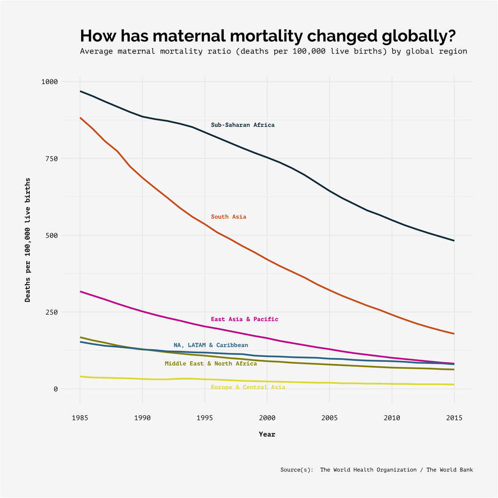

```r
###############
#  LINEGRAPH  #
###############

#### Create new data frame for world regions

copy_merged_WHO_WB_data <- merged_WHO_WB_data
copy_merged_WHO_WB_data$Region[copy_merged_WHO_WB_data$Region %in% c("North America", "Latin America & Caribbean")] <- "NA, LATAM & Caribbean"


# group and summarize merged WHO and WB data into a new table based on world region
region_data <- summarize(group_by(copy_merged_WHO_WB_data, year, Region),
                             avg_mmr=round(mean(value, na.rm=TRUE), digits=0))


#### PLOT

background_color <- "#F7F7F7"
gridline_color_light <- "#EBEBEB"
gridline_color_dark <- "#8A8A8A"
title_font <- "Raleway"
subtitle_font <- "PT Mono"
caption_font <- "PT Mono"
directlabel_font <- "PT Mono"


region_data2 <- region_data
# show_years <- c(2015, 2010, 2005, 2000, 1995, 1990, 1985)
# region_data2 <- subset(region_data2, year %in% show_years)

df <- region_data2

ggplot(data = df, aes(x = year, y = avg_mmr, group = Region)) +
  geom_line(aes(color = Region), size = 1.15) +
  geom_text(data = df %>% filter(year == 1995 & Region %in% c("Sub-Saharan Africa", "South Asia", "East Asia & Pacific")),
            aes(label = Region, color = Region),
            nudge_x = 0.5,
            nudge_y = 25,
            hjust = "left",
            fontface = "bold",
            size = 3,
            family = directlabel_font) +
  geom_text(data = df %>% filter(year == 1995 & Region %in% c("East Asia & Pacific")),
            aes(label = Region, color = Region),
            nudge_x = 0.5,
            nudge_y = 25,
            hjust = "left",
            fontface = "bold",
            size = 3,
            family = directlabel_font) +
  geom_text(data = df %>% filter(year == 1995 & Region %in% c("Europe & Central Asia")),
            aes(label = Region, color = Region),
            nudge_x = 0.5,
            nudge_y = -25,
            hjust = "left",
            fontface = "bold",
            size = 3,
            family = directlabel_font) +
  geom_text(data = df %>% filter(year == 1995 & Region %in% c("NA, LATAM & Caribbean")),
            aes(label = Region, color = Region),
            nudge_x = 0.5,
            nudge_y = 25,
            fontface = "bold",
            size = 3,
            family = directlabel_font) +
  geom_text(data = df %>% filter(year == 1995 & Region %in% c("Middle East & North Africa")),
            aes(label = Region, color = Region),
            nudge_x = 0.5,
            nudge_y = -25,
            fontface = "bold",
            size = 3,
            family = directlabel_font) +
  scale_color_manual(values = rev(c("#13394A", "#D46224", "#357797", "#948E00", "#E3DD44", "#CC149B"))) +
  scale_x_continuous(breaks = seq(1985, 2015, 5)) +
  labs(title = "",
       subtitle = "",
       caption = "Source(s):  The World Health Organization / The World Bank") +
  xlab("Year") +
  ylab("Deaths per 100,000 live births") +

  theme(
    axis.title = element_text(size = 10, family = "PT Mono", face = "bold", color = "black"),
    axis.title.x = element_text(margin = margin(t=0.5, r=0, b=0, l=0, unit="cm")),
    axis.title.y = element_text(margin = margin(t=0, r=0.5, b=0, l=0, unit="cm")),
    axis.text = element_text(size = 10, family = "PT Mono", color = "black"),
    axis.text.x = element_text(margin = margin(t=.5, r=0, b=0, l=0, unit="cm")),
    axis.ticks = element_blank(),

    legend.position = "none",

    panel.border = element_blank(),
    panel.background = element_rect(fill = background_color),
    panel.grid.major.x = element_line(color = gridline_color_light),
    panel.grid.minor.x = element_blank(),
    panel.grid.major.y = element_line(color = gridline_color_light),
    panel.grid.minor.y = element_line(color = gridline_color_light),

    plot.title = element_text(size = 20, family = "Raleway", face = "bold"),
    plot.subtitle = element_text(size = 10, family = "PT Mono",
                                 margin = margin(t=0,r=0,b=1.5,l=0,unit="cm")),
    plot.caption = element_text(size = 8,
                                family = "PT Mono",
                                margin = margin(t=1.5,r=0,b=0,l=0,unit="cm"),
                                hjust = 1),
    plot.margin = unit(c(.5,.5,.5,.5),"in"),
    plot.background = element_rect(fill = background_color)
  ) +

  coord_cartesian(xlim = c(1985,2015), ylim = c(1,max(df$avg_mmr)), clip = "off") +
  annotate("text", x = 1985, y = 1150, label = "How has maternal mortality changed globally?", size = 8.5, hjust = 0, fontface = "bold", family = title_font) +
  annotate("text", x = 1985, y = 1100, label = "Average maternal mortality ratio (deaths per 100,000 live births) by global region", size = 4, hjust = 0, family = subtitle_font)
```

Overall, maternal mortality ratios around the world have decreased in the last 30 years. However, maternal mortality remains high among childbearing women in Sub-Saharan African countries (482 maternal deaths per 100,000 live births). South Asian countries had a significant drop in maternal mortality, from 883 deaths to 179 deaths per live births.

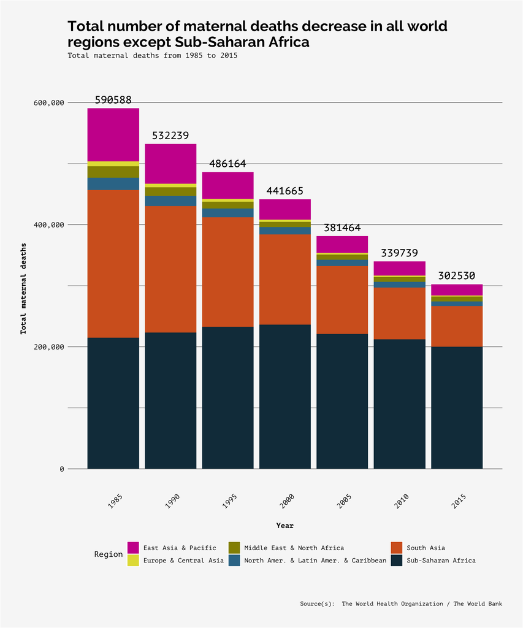

```r
#######################
#  STACKED BAR CHART  #
#######################

#### PREP

# read in World Health Organization data
WHO_data <- read.csv("data/WHO_MMR-data-1990-2015 (1)/countryresults_all.csv")

# read and clean World Bank data
WorldBank_data <- read_excel("data/old data/world bank data.xlsx")
WorldBank_data <- WorldBank_data[-c(1),]
WorldBank_data <- WorldBank_data[,-c(1,2,5)]

# create a new table of maternal mortality ratio point estimates
matdeath_data <- filter(WHO_data,
                   indicator == "matdeaths",
                   estimate == "point estimate",
                   rounded == "TRUE")

# merge WHO and WB data
new_data <- sqldf("SELECT * from matdeath_data
                  LEFT OUTER join WorldBank_data
                  ON matdeath_data.iso = WorldBank_data.Code")

show_years <- c(2015, 2010, 2005, 2000, 1995, 1990, 1985)
new_data <- subset(new_data, year %in% show_years)


rollup_new_data <- new_data
rollup_new_data$Region[rollup_new_data$Region %in% c("North America", "Latin America & Caribbean")] <- "North Amer. & Latin Amer. & Caribbean"


# group and summarize into a new table
sum_region_data <- summarize(group_by(rollup_new_data, year, Region),
                             total_matdeaths_region = round(sum(value, na.rm=TRUE), digits=0))


sum_year_data <- summarize(group_by(sum_region_data, year),
                             total_matdeaths_year = sum(total_matdeaths_region, na.rm=TRUE))

merge_data <- merge(sum_region_data, sum_year_data, by="year")


#### PLOT

df <- merge_data

gridline_color <- "#8A8A8A"
background_color <- "#F7F7F7"
stackedbar_colors <- rev(c("#13394A", "#D46224", "#357797", "#948E00", "#E3DD44", "#CC149B"))
geomtext_font <- "PT Mono"

ggplot(df, aes(x = year, y = total_matdeaths_region, fill = Region)) +
  geom_bar(stat = "identity") +
  scale_fill_manual(values = stackedbar_colors) +
  scale_x_continuous(breaks = seq(1985, 2015, 5)) +
  scale_y_continuous(labels = scales::comma) +
  geom_text(aes(y = total_matdeaths_year, label = total_matdeaths_year),
            size = 5,
            vjust = -.7,
            colour = "black",
            family = geomtext_font,
            face = "bold") +
  labs(title = "Total number of maternal deaths decrease in all world\nregions except Sub-Saharan Africa",
       subtitle = "Total maternal deaths from 1985 to 2015",
       caption = "Source(s):  The World Health Organization / The World Bank") +
  xlab("Year") +
  ylab("Total maternal deaths") +

  theme(
    axis.title = element_text(size = 10, family = "PT Mono", face = "bold", color = "black"),
    axis.title.x = element_text(margin = margin(t=0.3, r=0, b=0, l=0, unit="cm")),
    axis.title.y = element_text(margin = margin(t=0, r=0.3, b=0, l=0, unit="cm")),
    axis.text = element_text(size = 10, family = "PT Mono", color = "black"),
    axis.text.x = element_text(angle = 45, margin = margin(t=.5, r=0, b=0, l=0, unit="cm")),
    axis.ticks = element_blank(),

    legend.position = "bottom",
    legend.background = element_rect(fill = background_color),
    legend.title = element_text(family = "PT Mono"),
    legend.text = element_text(family = "PT Mono"),

    panel.border = element_blank(),
    panel.background = element_rect(fill = background_color),
    panel.grid.major.x = element_blank(),
    panel.grid.minor.x = element_blank(),
    panel.grid.major.y = element_line(color = gridline_color),
    panel.grid.minor.y = element_line(color = gridline_color),

    plot.title = element_text(size = 20, family = "Raleway", face = "bold"),
    plot.subtitle = element_text(size = 10, family = "PT Mono",
                                 margin = margin(t=0,r=0,b=1.5,l=0,unit="cm")),
    plot.caption = element_text(size = 8,
                                family = "PT Mono",
                                margin = margin(t=1.5,r=0,b=0,l=0,unit="cm"),
                                hjust = 1),
    plot.margin = unit(c(1,1,1,1),"cm"),
    plot.background = element_rect(fill = background_color)
  ) +
  # theme(
  #
  #   plot.title = element_text(size = 20, face = "bold"),
  #   plot.subtitle = element_text(size = 10, margin = margin(t=0,r=0,b=1.5,l=0,unit="cm")),
  #   plot.caption = element_text(size = 7,
  #                               margin = margin(t=1.5,r=0,b=0,l=0,unit="cm"),
  #                               hjust = 1.5,
  #                               face = "italic"),
  #   plot.margin = unit(c(.75,.75,.75,.75),"in")
  #   ) +
  coord_cartesian(clip = "off")
```

The prior line chart shows that maternal mortality ratios have decreased, and we see in this stacked bar chart that total Sub-Saharan African maternal deaths remains the same around 200,000. While live births have increased in Sub-Saharan Africa, childbearing women in those countries have continued to die at the same levels over the past 30 years. Total maternal deaths in Europe & Central Asia are so low compared to other regions that they almost appear invisible by 2015.

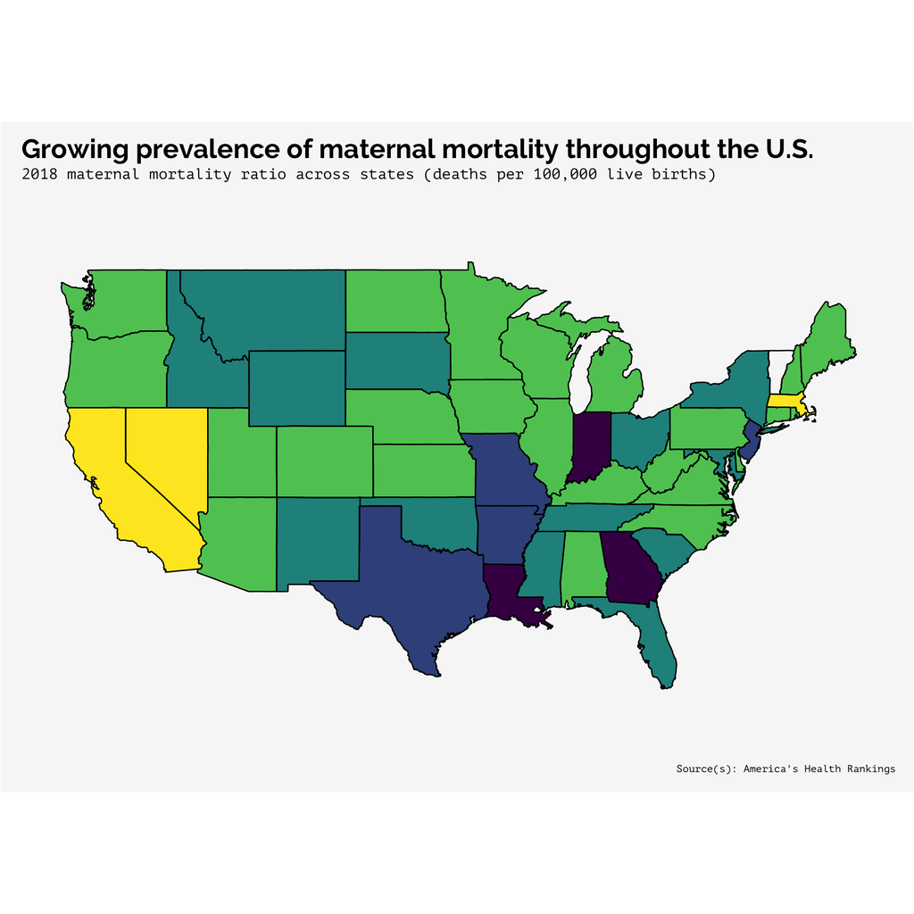

```r
######################
#  CHOROPLETH MAP 1  #
######################

AHR_data <- read.csv("data/2018-HWC (4).csv")

AHR_mma_US <- subset(AHR_data, AHR_data$Measure.Name == "Maternal Mortality")

states <- map_data("state")

AHR_mma_US$bucket <- rep(NA, length(AHR_mma_US$State.Name))
AHR_mma_US$bucket[which(AHR_mma_US$Value < 10)] <- "[1-10)"
AHR_mma_US$bucket[which(AHR_mma_US$Value >= 10 & AHR_mma_US$Value < 20)] <- "[10-20)"
AHR_mma_US$bucket[which(AHR_mma_US$Value >= 20 & AHR_mma_US$Value < 30)] <- "[20-30)"
AHR_mma_US$bucket[which(AHR_mma_US$Value >= 30 & AHR_mma_US$Value < 40)] <- "[30-40)"
AHR_mma_US$bucket[which(AHR_mma_US$Value >= 40)] <- "40+"


####  PLOT

AHR_mma_US$region <- tolower(AHR_mma_US$State.Name)

US_mmr <- merge(states, AHR_mma_US, by="region", all.x=T)
US_mmr <- US_mmr[order(US_mmr$order),]

ggplot(US_mmr, aes(x=long,y=lat,group=group))+
  geom_polygon(aes(fill=factor(bucket)))+
  scale_fill_viridis_d(option = "D", direction = -1) +
  # geom_polygon(aes(fill=Value))+
  # scale_fill_viridis_c(option = "D", direction = -1) +
  geom_path()+
  coord_map() +
  labs(title = "Growing prevalence of maternal mortality throughout the U.S.",
       subtitle = "2018 maternal mortality ratio across states (deaths per 100,000 live births)",
       caption = "Source(s): America's Health Rankings") +
  theme(
    axis.title = element_blank(),
    axis.title.x = element_blank(),
    axis.title.y = element_blank(),
    axis.text.x = element_blank(),
    axis.text.y = element_blank(),
    axis.ticks = element_blank(),

    legend.position = "none",

    panel.border = element_blank(),
    panel.grid.major.y = element_blank(),
    panel.grid.minor.y = element_blank(),
    panel.grid.major.x = element_blank(),
    panel.grid.minor.x = element_blank(),
    panel.background = element_rect(fill = "#F7F7F7"),

    plot.title = element_text(size = 21, family = "Raleway", face = "bold"),
    plot.subtitle = element_text(size = 12, family = "PT Mono",
                                 margin = margin(t=0,r=0,b=1.5,l=0,unit="cm")),
    plot.caption = element_text(size = 8,
                                family = "PT Mono",
                                margin = margin(t=1.5,r=0,b=0,l=0,unit="cm"),
                                hjust = 1),
    plot.margin = unit(c(0.5, 0.5, 0.5, 0.5),"cm"),
    plot.background = element_rect(fill = "#F7F7F7")
  )
```

```r
#code for heatmap of US from https://stackoverflow.com/questions/24441775/how-do-you-create-a-us-states-heatmap-based-on-some-values
```

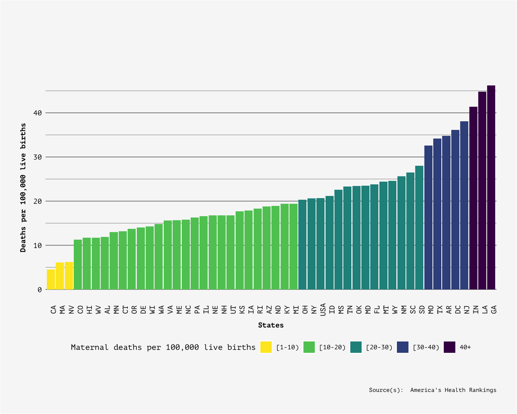

```r
###############
#  BAR CHART  #
###############

AHR_data <- read.csv("data/2018-HWC (4).csv")

AHR_mma_US <- subset(AHR_data, AHR_data$Measure.Name == "Maternal Mortality")

AHR_mma_US$bucket <- rep(NA, length(AHR_mma_US$State.Name))
AHR_mma_US$bucket[which(AHR_mma_US$Value < 10)] <- "[1-10)"
AHR_mma_US$bucket[which(AHR_mma_US$Value >= 10 & AHR_mma_US$Value < 20)] <- "[10-20)"
AHR_mma_US$bucket[which(AHR_mma_US$Value >= 20 & AHR_mma_US$Value < 30)] <- "[20-30)"
AHR_mma_US$bucket[which(AHR_mma_US$Value >= 30 & AHR_mma_US$Value < 40)] <- "[30-40)"
AHR_mma_US$bucket[which(AHR_mma_US$Value >= 40)] <- "40+"

stateabbr2 = data.frame(name=c("District of Columbia", "United States"), abbr=c("DC", "USA"))
stateabbr = data.frame(name=state.name, abbr=state.abb)
stateNabb <- rbind(stateabbr, stateabbr2)


US_mmr <- merge(AHR_mma_US, stateNabb, by.x = c("State.Name"), by.y = c("name"))
US_mmr <- filter(US_mmr, !abbr %in% c("VT", "AK"))

df <- US_mmr

# barchart <- ggplot(df, aes(x = reorder(abbr, -Value), y = Value, fill = bucket)) +
barchart <- ggplot(df, aes(x = reorder(abbr, Value), y = Value, fill = bucket)) +
  geom_bar(stat = "identity") +
  # scale_fill_viridis_c(option = "D", direction = -1) +
  scale_fill_viridis_d(option = "D", direction = -1) +

  labs(title = "",
       subtitle = "",
       caption = "Source(s):  America's Health Rankings",
       fill = "Maternal deaths per 100,000 live births") +
  xlab("States") +
  ylab("Deaths per 100,000 live births") +

  theme(
    axis.title = element_text(size = 10, family = "PT Mono", face = "bold", color = "black"),
    axis.title.x = element_text(margin = margin(t=0.3, r=0, b=0, l=0, unit="cm")),
    axis.title.y = element_text(margin = margin(t=0, r=0.3, b=0, l=0, unit="cm")),
    axis.ticks = element_blank(),
    axis.text = element_text(size = 10, family = "PT Mono", color = "black"),
    axis.text.x = element_text(angle = 90),

    legend.position = "bottom",
    legend.background = element_rect(fill = "#F7F7F7"),
    legend.text = element_text(family = "PT Mono"),
    legend.title = element_text(family = "PT Mono"),

    panel.border = element_blank(),
    panel.background = element_rect(fill = "#F7F7F7"),
    panel.grid.major.x = element_blank(),
    panel.grid.minor.x = element_blank(),
    panel.grid.major.y = element_line(color = "#8A8A8A"),
    panel.grid.minor.y = element_line(color = "#8A8A8A"),

    plot.title = element_text(size = 21, family = "Raleway", face = "bold"),
    plot.subtitle = element_text(size = 12, family = "PT Mono",
                                 margin = margin(t=0,r=0,b=1.5,l=0,unit="cm")),
    plot.caption = element_text(size = 8,
                                family = "PT Mono",
                                margin = margin(t=1.5,r=0,b=0,l=0,unit="cm"),
                                hjust = 1),
    plot.margin = unit(c(1,1,1,1),"cm"),
    plot.background = element_rect(fill = "#F7F7F7")
  )
plot(barchart)
```

Choropleth and bar chart: Above visualizes maternal deaths per 100,000 live births, inclusive of deaths that occur during gestation and up to 42 days after termination of pregnancy. The increasing ratio of maternal mortality is spread throughout the United States. Only a few states (California, Massachusetts, and Nevada) have low mortality ratios. Note: Data not available for Alaska and Vermont.

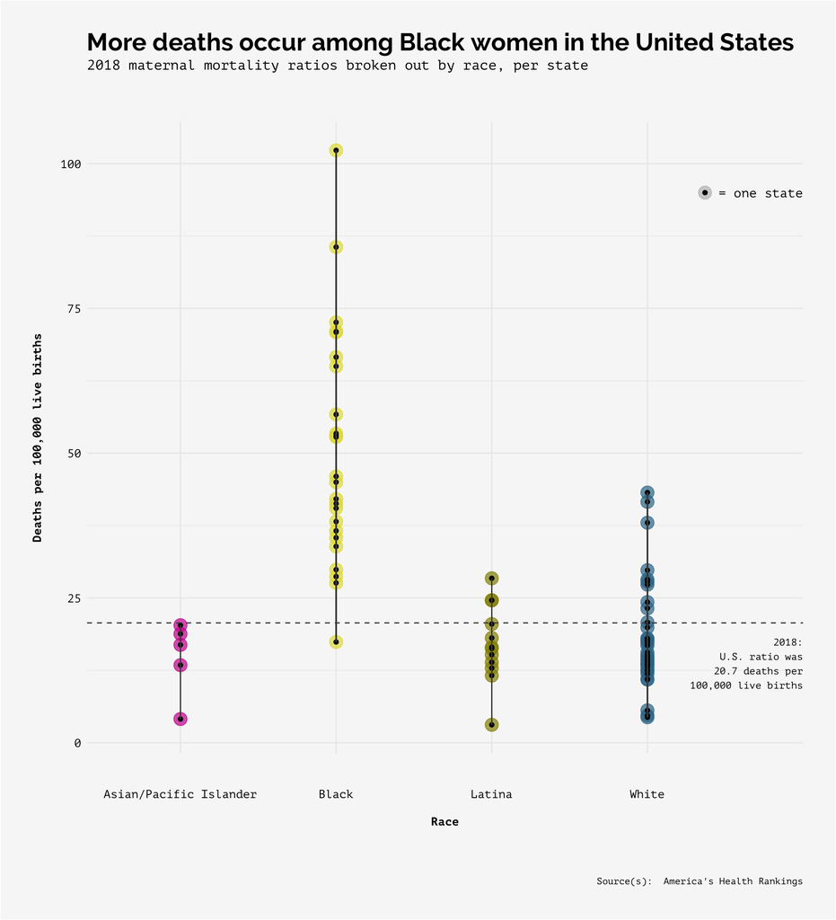

```r
####################
#  DOT PLOT - Race #
####################

AHR_data <- read.csv("data/2018-HWC (4).csv")

keep <- c("Maternal Mortality - AIAN","Maternal Mortality - Asian/Pacific Islander","Maternal Mortality - Black","Maternal Mortality - Hispanic","Maternal Mortality - White")
AHR_mmr_by_race <- filter(AHR_data, AHR_data$Measure.Name %in% keep)

#If you want region of the country:
northeast <- c("Connecticut", "Maine", "Massachusetts", "New Hampshire", "Rhode Island", "Vermont", "New Jersey", "New York", "Pennsylvania")
midwest <- c("Illinois","Indiana","Michigan","Ohio","Wisconsin","Iowa","Kansas","Minnesota","Missouri","Nebraska","North Dakota","South Dakota")
south <- c("Delaware","District of Columbia","Florida","Georgia","Maryland","North Carolina","South Carolina","Virginia","West Virginia","Alabama","Kentucky","Mississippi","Tennessee","Arkansas","Louisiana","Oklahoma","Texas")
west <- c("Arizona","Colorado","Idaho","Montana","Nevada","New Mexico","Utah","Wyoming","Alaska","California","Hawaii","Oregon","Washington")

AHR_mmr_by_race <- mutate(AHR_mmr_by_race, Region = case_when(State.Name %in% northeast ~ "Northeast",
                                                              State.Name %in% midwest ~ "Midwest",
                                                              State.Name %in% south ~ "South",
                                                              State.Name %in% west ~ "West"))

AHR_mmr_by_race <- drop_na(AHR_mmr_by_race, c("Value"))
AHR_mmr_by_race <- filter(AHR_mmr_by_race, State.Name != "United States") #remove "US" observation

AHR_mmr_by_race <- mutate(AHR_mmr_by_race, Race = case_when(Measure.Name == "Maternal Mortality - AIAN" ~ "AIAN",
                                                            Measure.Name == "Maternal Mortality - Asian/Pacific Islander" ~ "Asian/Pacific Islander",
                                                            Measure.Name == "Maternal Mortality - Black" ~ "Black",
                                                            Measure.Name == "Maternal Mortality - Hispanic" ~ "Latina",
                                                            Measure.Name == "Maternal Mortality - White" ~ "White"))

# drop AIAN because only one observation
AHR_mmr_by_race <- filter(AHR_mmr_by_race, Race != "AIAN")

# if labeling states
stateabbr2 = data.frame(name=c("District of Columbia", "United States"), abbr=c("DC", "USA"))
stateabbr = data.frame(name=state.name, abbr=state.abb)
stateNabb <- rbind(stateabbr, stateabbr2)

AHR_race <- merge(AHR_mmr_by_race, stateNabb, by.x = c("State.Name"), by.y = c("name"))


segcolor <- "#4A4A4A"
racecolors <- c("#CC149B", "#E3DD44", "#948E00", "#357797")
gridlinecolor <- "#EBEBEB"

df <- AHR_race


ggplot(df, aes(x = Race, y = Value, colour = Race)) +
  geom_point(size = 5, alpha = 0.7) +
  # geom_text(aes(label = abbr), color = "black", vjust = "center", nudge_x = 0.15, check_overlap = TRUE) +
  scale_colour_manual(values = racecolors) +

  geom_point(size = 1.5, color = "black") +

  geom_segment(aes(x = 1, xend = 1, y = 4.1, yend = 20.3), color = segcolor, alpha = 0.6) + #Asian/PI
  geom_segment(aes(x = 2, xend = 2, y = 17.4, yend = 102.3), color = segcolor, alpha = 0.6) + #Black
  geom_segment(aes(x = 3, xend = 3, y = 3.1, yend = 28.4), color = segcolor, alpha = 0.6) + #Latina
  geom_segment(aes(x = 4, xend = 4, y = 4.4, yend = 43.2), color = segcolor, alpha = 0.6) + #White


  geom_hline(yintercept = 20.7, linetype = "dashed", color = segcolor) +

  labs(title = "More deaths occur among Black women in the United States",
       subtitle = "2018 maternal mortality ratios broken out by race, per state",
       caption = "Source(s):  America's Health Rankings") +
  xlab("Race") +
  ylab("Deaths per 100,000 live births") +

  theme(
    axis.title = element_text(size = 10, family = "PT Mono", face = "bold", color = "black"),
    axis.title.x = element_text(margin = margin(t=0.5, r=0, b=0, l=0, unit="cm")),
    axis.title.y = element_text(margin = margin(t=0, r=0.5, b=0, l=0, unit="cm")),
    axis.text = element_text(size = 10, family = "PT Mono", color = "black"),
    axis.text.x = element_text(margin = margin(t=1, r=0, b=0, l=0, unit="cm")),
    axis.ticks = element_blank(),

    legend.position = "none",

    panel.border = element_blank(),
    panel.background = element_rect(fill = "#F7F7F7"),
    panel.grid.major.x = element_line(color = "#EBEBEB"),
    panel.grid.minor.x = element_line(color = "#EBEBEB"),
    panel.grid.major.y = element_line(color = "#EBEBEB"),
    panel.grid.minor.y = element_line(color = "#EBEBEB"),

    plot.title = element_text(size = 21, family = "Raleway", face = "bold"),
    plot.subtitle = element_text(size = 12, family = "PT Mono",
                                 margin = margin(t=0,r=0,b=1.5,l=0,unit="cm")),
    plot.caption = element_text(size = 8,
                                family = "PT Mono",
                                margin = margin(t=1.5,r=0,b=0,l=0,unit="cm"),
                                hjust = 1),
    plot.margin = unit(c(1,1,1,1),"cm"),
    plot.background = element_rect(fill = "#F7F7F7")
  ) +

  coord_cartesian(clip = "off") +

  annotate("text", x = 5, y = 18, label = "2018:\nU.S. ratio was\n20.7 deaths per\n100,000 live births", size = 3, hjust = "right", vjust = "top", family = "PT Mono") +

  annotate("point", x = 4.37, y = 95, size = 5, alpha = 0.7, color = "grey") +
  annotate("point", x = 4.37, y = 95, size = 1.5, color = "black") +
  annotate("text", x = 5, y = 95, hjust = "right", label = " = one state", family = "PT Mono")
```

```r
###
```

Noticeably, maternal death affects Black women in the United States at higher ratios, having at its highest point 102.3 deaths per 100,000 live births. Where states are represented by dots on this graph, there is minimal state collection/reporting of maternal mortality by race. Most data is collected on Black and White women (24 and 37 state observations, respectively). Note: American Indian/Alaskan Native women were not visualized on this graph because of minimal data.

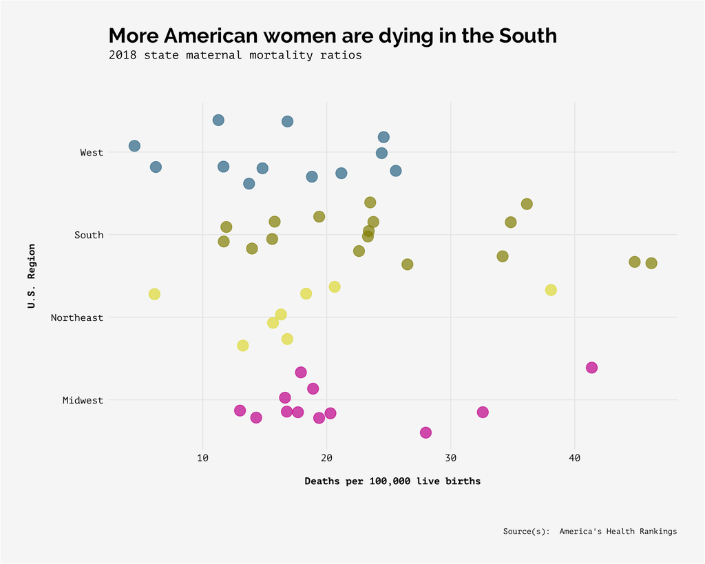

```r
###############################
#  SCATTER PLOT - US Regions  #
###############################

AHR_data <- read.csv("data/2018-HWC (4).csv")


AHR_by_region <- filter(AHR_data, AHR_data$Measure.Name == "Maternal Mortality")

#If you want region of the country:
northeast <- c("Connecticut", "Maine", "Massachusetts", "New Hampshire", "Rhode Island", "Vermont", "New Jersey", "New York", "Pennsylvania")
midwest <- c("Illinois","Indiana","Michigan","Ohio","Wisconsin","Iowa","Kansas","Minnesota","Missouri","Nebraska","North Dakota","South Dakota")
south <- c("Delaware","District of Columbia","Florida","Georgia","Maryland","North Carolina","South Carolina","Virginia","West Virginia","Alabama","Kentucky","Mississippi","Tennessee","Arkansas","Louisiana","Oklahoma","Texas")
west <- c("Arizona","Colorado","Idaho","Montana","Nevada","New Mexico","Utah","Wyoming","Alaska","California","Hawaii","Oregon","Washington")

AHR_by_region <- mutate(AHR_by_region, Region = case_when(State.Name %in% northeast ~ "Northeast",
                                                              State.Name %in% midwest ~ "Midwest",
                                                              State.Name %in% south ~ "South",
                                                              State.Name %in% west ~ "West"))

AHR_by_region <- drop_na(AHR_by_region, c("Value"))
AHR_by_region <- filter(AHR_by_region, State.Name != "United States") #remove "US" observation


# if labeling states
stateabbr2 = data.frame(name=c("District of Columbia", "United States"), abbr=c("DC", "USA"))
stateabbr = data.frame(name=state.name, abbr=state.abb)
stateNabb <- rbind(stateabbr, stateabbr2)

AHR_by_region2 <- merge(AHR_by_region, stateNabb, by.x = c("State.Name"), by.y = c("name"))


region_colors <- c("#CC149B", "#E3DD44", "#948E00", "#357797")
gridlinecolor <- "#EBEBEB"

df <- AHR_by_region2


ggplot(df, aes(x = Value, y = Region, colour = Region)) +
  geom_jitter(size = 5, alpha = 0.7) +
  scale_colour_manual(values = region_colors) +

  labs(title = "More American women are dying in the South",
       subtitle = "2018 state maternal mortality ratios",
       caption = "Source(s):  America's Health Rankings") +
  xlab("Deaths per 100,000 live births") +
  ylab("U.S. Region") +

  theme(
    axis.title = element_text(size = 10, family = "PT Mono", face = "bold", color = "black"),
    axis.title.x = element_text(margin = margin(t=0.5, r=0, b=0, l=0, unit="cm")),
    axis.title.y = element_text(margin = margin(t=0, r=0.5, b=0, l=0, unit="cm")),
    axis.text = element_text(size = 10, family = "PT Mono", color = "black"),
    axis.ticks = element_blank(),

    legend.position = "none",

    panel.border = element_blank(),
    panel.background = element_rect(fill = "#F7F7F7"),
    panel.grid.major.x = element_line(color = "#EBEBEB"),
    panel.grid.minor.x = element_blank(),
    panel.grid.major.y = element_line(color = "#EBEBEB"),
    panel.grid.minor.y = element_blank(),

    plot.title = element_text(size = 21, family = "Raleway", face = "bold"),
    plot.subtitle = element_text(size = 12, family = "PT Mono",
                                 margin = margin(t=0,r=0,b=1.5,l=0,unit="cm")),
    plot.caption = element_text(size = 8,
                                family = "PT Mono",
                                margin = margin(t=1.5,r=0,b=0,l=0,unit="cm"),
                                hjust = 1),
    plot.margin = unit(c(1,1,1,1),"cm"),
    plot.background = element_rect(fill = "#F7F7F7")
  ) +

  coord_cartesian(clip = "off")
```

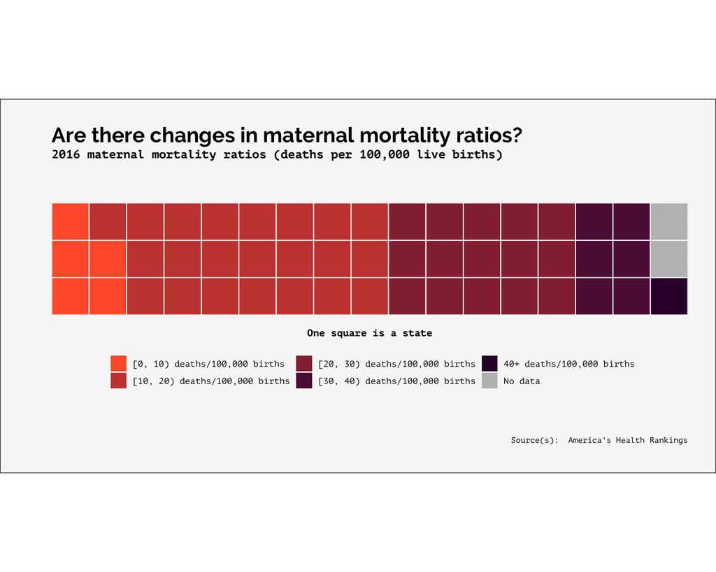

```r
#################
#  2016 WAFFLE  #
#################

AHR_2016data <- read.csv("data/2016-HWC.csv")


AHR_2016allstates <- filter(AHR_2016data, AHR_2016data$Measure.Name == "Maternal Mortality")


AHR_2016allstates <- filter(AHR_2016allstates, State.Name != "United States") #remove "US" observation


# if labeling states
stateabbr2 = data.frame(name=c("District of Columbia"), abbr=c("DC"))
stateabbr = data.frame(name=state.name, abbr=state.abb)
stateNabb <- rbind(stateabbr, stateabbr2)

AHR_2016 <- merge(AHR_2016allstates, stateNabb, by.x = c("State.Name"), by.y = c("name"))

AHR_2016$bucket <- rep(NA, length(AHR_2016$State.Name))
AHR_2016$bucket[which(AHR_2016$Value < 10)] <- "1-9"
AHR_2016$bucket[which(AHR_2016$Value >= 10 & AHR_2016$Value < 20)] <- "10-19"
AHR_2016$bucket[which(AHR_2016$Value >= 20 & AHR_2016$Value < 30)] <- "20-29"
AHR_2016$bucket[which(AHR_2016$Value >= 30 & AHR_2016$Value < 40)] <- "30-39"
AHR_2016$bucket[which(AHR_2016$Value >= 40)] <- "40+"


parts <- c("[0, 10) deaths/100,000 births" = 5,
           "[10, 20) deaths/100,000 births" = 22,
           "[20, 30) deaths/100,000 births" = 15,
           "[30, 40) deaths/100,000 births" = 6,
           "40+ deaths/100,000 births" = 1,
           "No data" = 2)

waffle(parts, rows = 3, size = .5,
       colors = rev(c("grey", "#330136", "#5E1742", "#962E40", "#C9463D","#FF5E35"))) +
  labs(title = "Are there changes in maternal mortality ratios?",
       subtitle = "2016 maternal mortality ratios (deaths per 100,000 live births)",
       caption = "Source(s):  America's Health Rankings") +
  xlab("One square is a state") +
  ylab("") +

  theme(
    axis.title = element_text(size = 10, family = "PT Mono", face = "bold", color = "black"),
    axis.title.x = element_text(margin = margin(t=0.5, r=0, b=0, l=0, unit="cm")),
    axis.title.y = element_text(margin = margin(t=0, r=0.5, b=0, l=0, unit="cm")),
    axis.text = element_blank(),
    axis.ticks = element_blank(),

    legend.position = "bottom",
    legend.text = element_text(family = "PT Mono"),

    panel.border = element_blank(),
    panel.background = element_rect(fill = "#F7F7F7"),
    panel.grid.major.x = element_line(color = "#EBEBEB"),
    panel.grid.minor.x = element_blank(),
    panel.grid.major.y = element_line(color = "#EBEBEB"),
    panel.grid.minor.y = element_blank(),

    plot.title = element_text(size = 21, family = "Raleway", face = "bold"),
    plot.subtitle = element_text(size = 12, family = "PT Mono", face = "bold",
                                 margin = margin(t=0,r=0,b=1.5,l=0,unit="cm")),
    plot.caption = element_text(size = 8,
                                family = "PT Mono",
                                margin = margin(t=1.5,r=0,b=0,l=0,unit="cm"),
                                hjust = 1),
    plot.margin = unit(c(1,1,1,1),"cm"),
    plot.background = element_rect(fill = "#F7F7F7")
  )
```

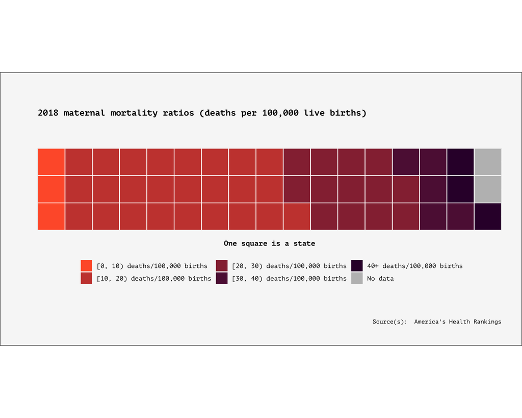

```r
############
#  WAFFLE  #
############

AHR_2018data <- read.csv("data/2018-HWC (4).csv")


AHR_2018allstates <- filter(AHR_2018data, AHR_2018data$Measure.Name == "Maternal Mortality")


AHR_2018allstates <- filter(AHR_2018allstates, State.Name != "United States") #remove "US" observation


# if labeling states
stateabbr2 = data.frame(name=c("District of Columbia"), abbr=c("DC"))
stateabbr = data.frame(name=state.name, abbr=state.abb)
stateNabb <- rbind(stateabbr, stateabbr2)

AHR_2018 <- merge(AHR_2018allstates, stateNabb, by.x = c("State.Name"), by.y = c("name"))

AHR_2018$bucket <- rep(NA, length(AHR_2018$State.Name))
AHR_2018$bucket[which(AHR_2018$Value < 10)] <- "1-9"
AHR_2018$bucket[which(AHR_2018$Value >= 10 & AHR_2018$Value < 20)] <- "10-19"
AHR_2018$bucket[which(AHR_2018$Value >= 20 & AHR_2018$Value < 30)] <- "20-29"
AHR_2018$bucket[which(AHR_2018$Value >= 30 & AHR_2018$Value < 40)] <- "30-39"
AHR_2018$bucket[which(AHR_2018$Value >= 40)] <- "40+"


parts <- c("[0, 10) deaths/100,000 births" = 3,
           "[10, 20) deaths/100,000 births" = 25,
           "[20, 30) deaths/100,000 births" = 13,
           "[30, 40) deaths/100,000 births" = 5,
           "40+ deaths/100,000 births" = 3,
           "No data" = 2)

waffle(parts, rows = 3, size = .5,
       colors = rev(c("grey", "#330136", "#5E1742", "#962E40", "#C9463D","#FF5E35"))) +
  labs(title = "",
       subtitle = "2018 maternal mortality ratios (deaths per 100,000 live births)",
       caption = "Source(s):  America's Health Rankings",
       fill = "Maternal deaths per 100,000 live births") +
  xlab("One square is a state") +
  ylab("") +

  theme(
    axis.title = element_text(size = 10, family = "PT Mono", face = "bold", color = "black"),
    axis.title.x = element_text(margin = margin(t=0.5, r=0, b=0, l=0, unit="cm")),
    axis.title.y = element_text(margin = margin(t=0, r=0.5, b=0, l=0, unit="cm")),
    axis.text = element_blank(),
    axis.ticks = element_blank(),

    legend.position = "bottom",
    legend.text = element_text(family = "PT Mono"),

    panel.border = element_blank(),
    panel.background = element_rect(fill = "#F7F7F7"),
    panel.grid.major.x = element_line(color = "#EBEBEB"),
    panel.grid.minor.x = element_blank(),
    panel.grid.major.y = element_line(color = "#EBEBEB"),
    panel.grid.minor.y = element_blank(),

    plot.title = element_text(size = 21, family = "Raleway", face = "bold"),
    plot.subtitle = element_text(size = 12, family = "PT Mono", face = "bold",
                                 margin = margin(t=0,r=0,b=1.5,l=0,unit="cm")),
    plot.caption = element_text(size = 8,
                                family = "PT Mono",
                                margin = margin(t=1.5,r=0,b=0,l=0,unit="cm"),
                                hjust = 1),
    plot.margin = unit(c(1,1,1,1),"cm"),
    plot.background = element_rect(fill = "#F7F7F7")
  )
```

Two waffle charts: From 2016 to 2018, we can see that more states have shifted into the maternal mortality ration range of [10 - 20) deaths. 2016 showed more states with low (0-10) death ratios, have decreased from 5 to 3 states. There has also been an increase in the number of states with high (40+) death ratios, from 1 to 3 states. Currently, 48% of states have maternal death ratios between 10-19 deaths; 25% of states between 20-29 deaths. Note: Data not available for Alaska and Vermont.

### Data Source(s):

- The World Bank: https://datahelpdesk.worldbank.org/knowledgebase/articles/906519-world-bank-country-and-lending-groups
- The World Health Organization: https://www.who.int/reproductivehealth/publications/monitoring/maternal-mortality-2015/en/
- America’s Health Rankings: https://www.americashealthrankings.org/explore/health-of-women-and-children/measure/maternal_mortality/state/ALL